# Multi-Sample Multi-condition Cell-Cell Communication Analysis via NicheNet: MIS-C application: All-vs-All

```r
circos_A = make_circos_one_group(prioritized_tbl_oi_A_30, colors_sender, colors_receiver)
```

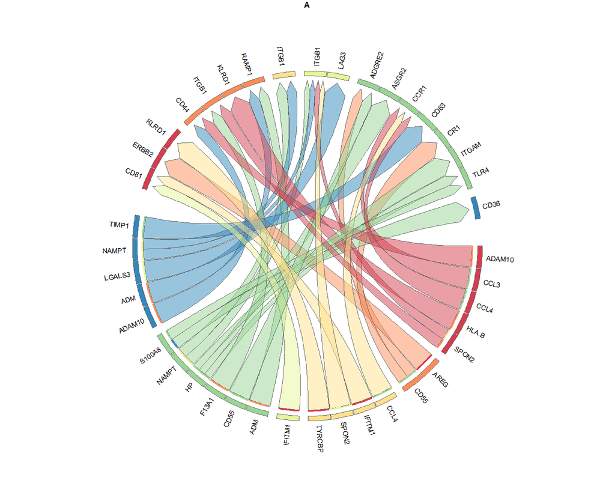

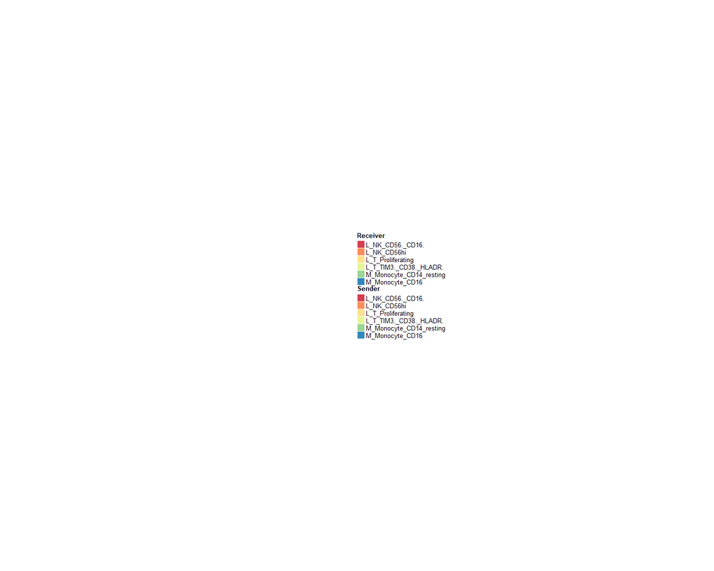

```r
circos_M = make_circos_one_group(prioritized_tbl_oi_M_30, colors_sender, colors_receiver)
```

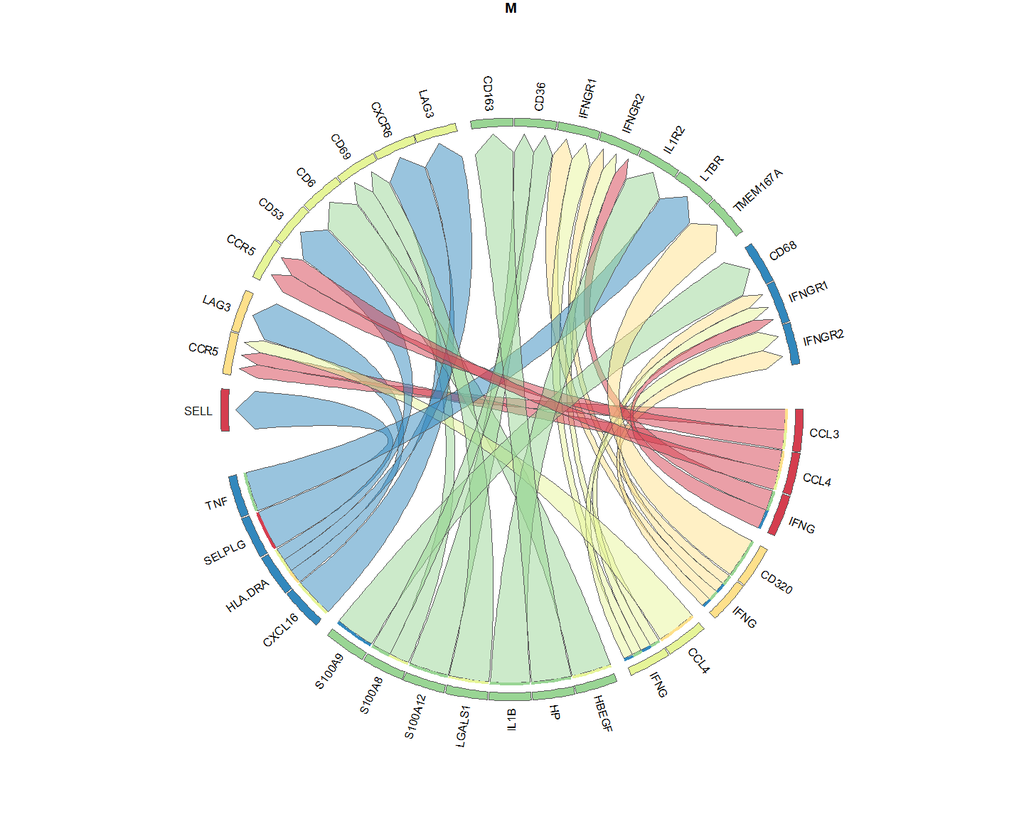

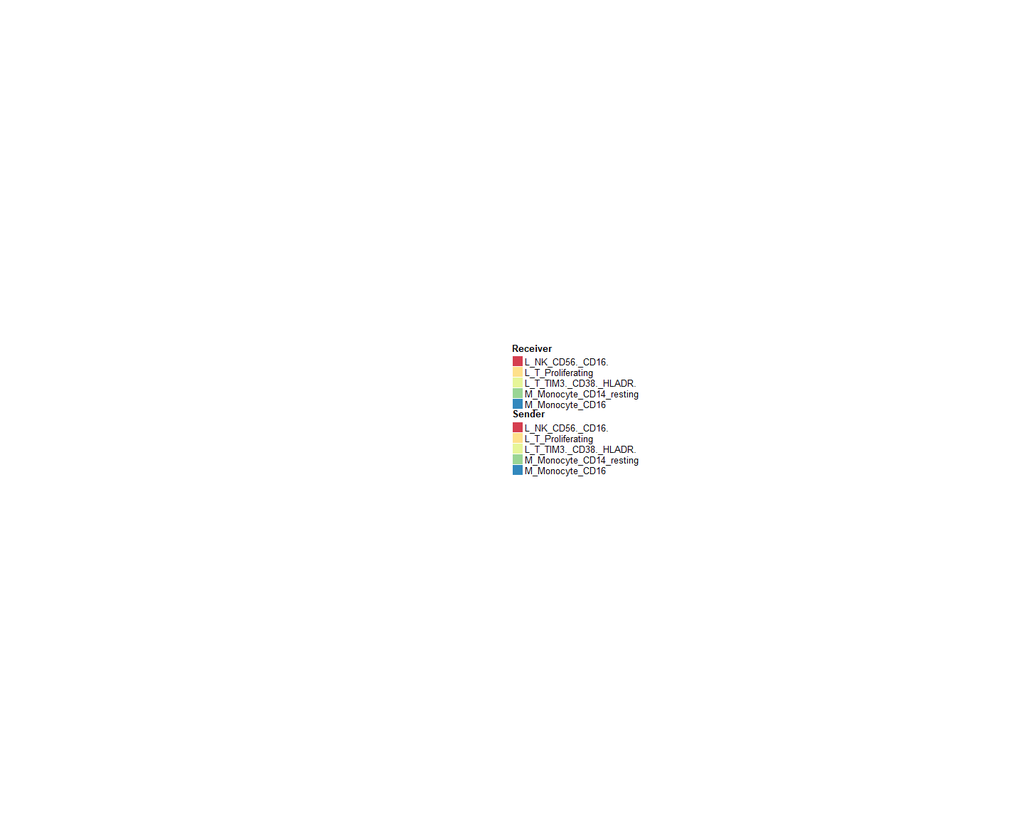

```r
circos_S = make_circos_one_group(prioritized_tbl_oi_S_30, colors_sender, colors_receiver)
```

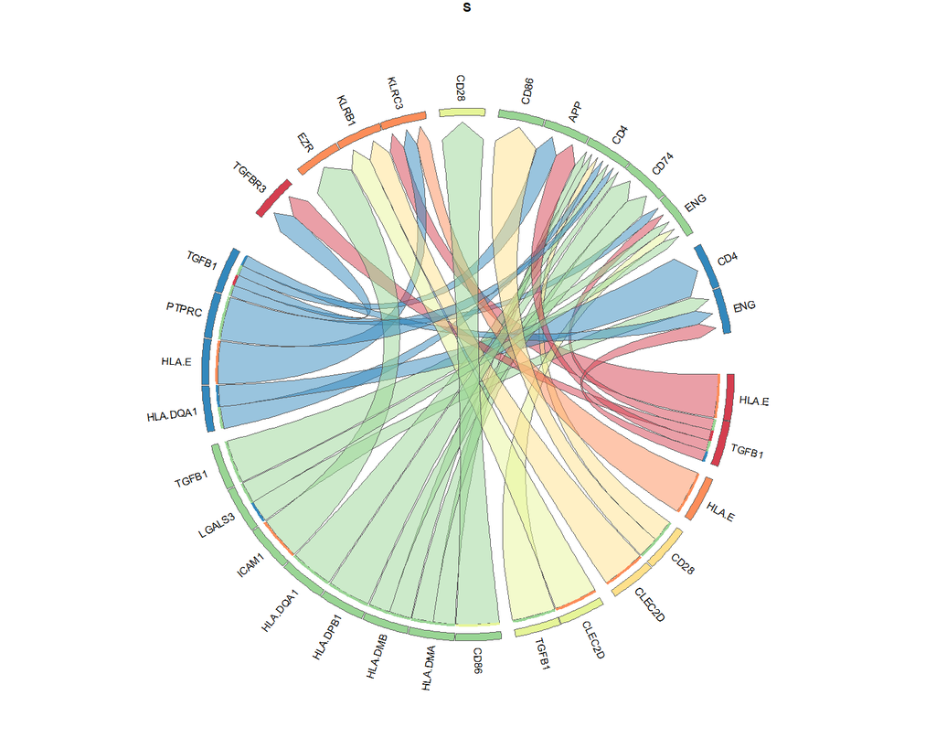

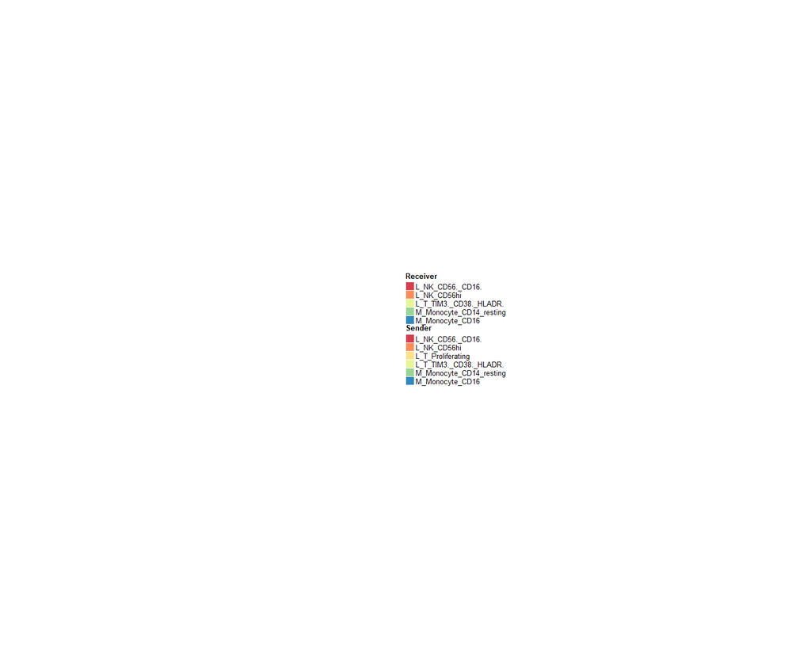

## Visualization of scaled ligand-receptor pseudobulk products and ligand activity

Now we will visualize per sample the scaled product of ligand and receptor expression. Samples that were left out of the DE analysis are indicated with a smaller dot (this helps to indicate the samples that did not contribute to the calculation of the logFC, and thus not contributed to the final prioritization)

We will now check the top 50 interactions specific for the MIS-C group

```r
group_oi = "M"
```

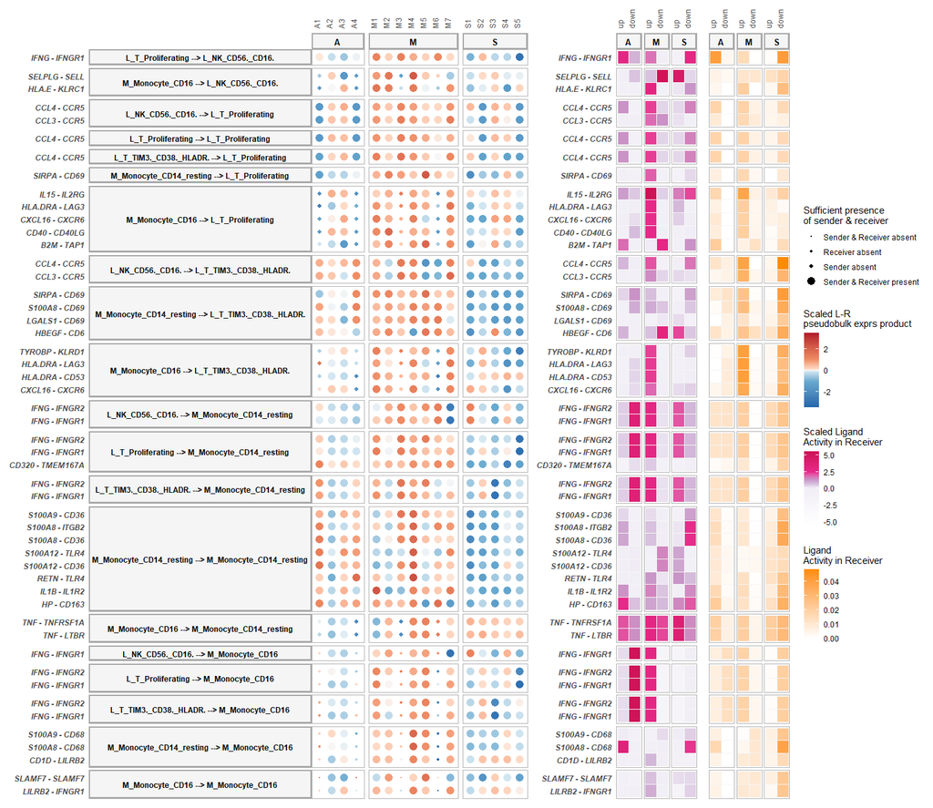

```r
prioritized_tbl_oi_M_50 = get_top_n_lr_pairs(multinichenet_output$prioritization_tables, 50, groups_oi = group_oi)

plot_oi = make_sample_lr_prod_activity_plots(multinichenet_output$prioritization_tables, prioritized_tbl_oi_M_50)
plot_oi
```

Typically, there are way more than 50 differentially expressed and active ligand-receptor pairs per group across all sender-receiver combinations. Therefore it might be useful to zoom in on specific cell types as senders/receivers:

Eg M_Monocyte_CD16 as receiver:

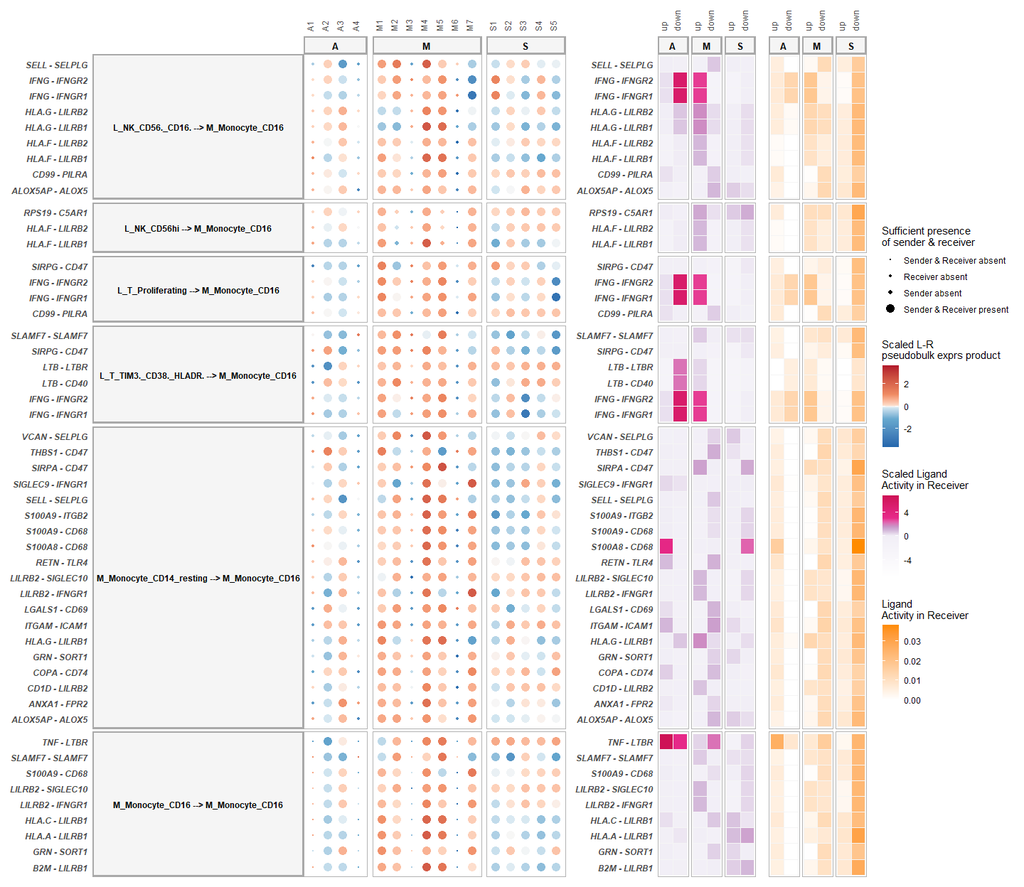

```r
prioritized_tbl_oi_M_50 = get_top_n_lr_pairs(multinichenet_output$prioritization_tables, 50, groups_oi = group_oi, receivers_oi = "M_Monocyte_CD16")

plot_oi = make_sample_lr_prod_activity_plots(multinichenet_output$prioritization_tables, prioritized_tbl_oi_M_50)
plot_oi
```

Eg M_Monocyte_CD16 as sender:

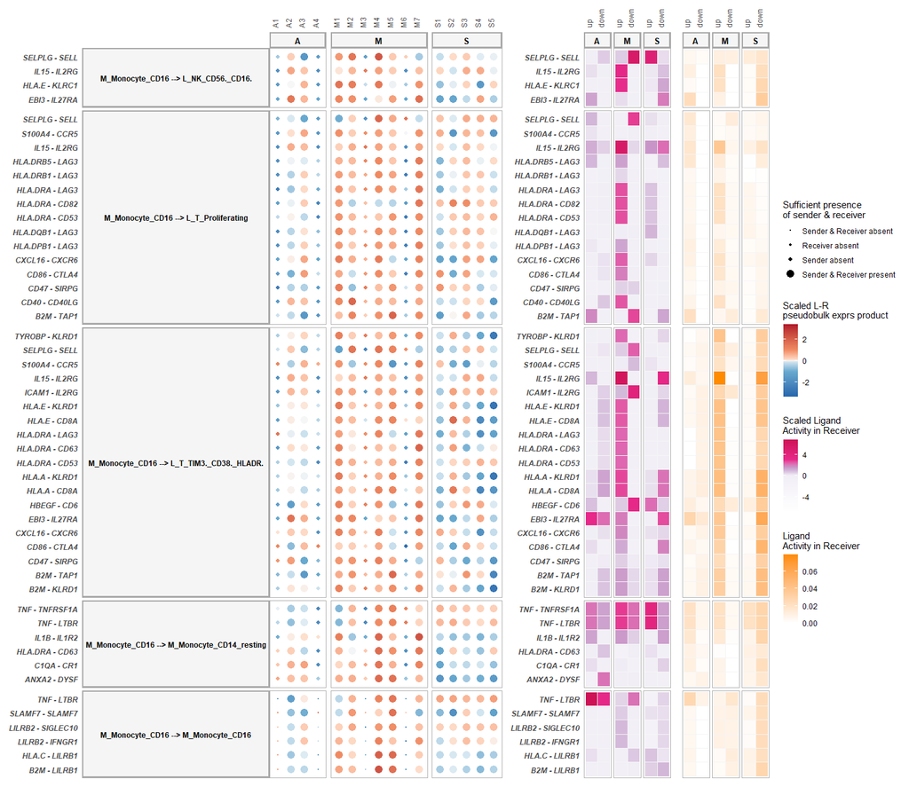

```r
prioritized_tbl_oi_M_50 = get_top_n_lr_pairs(multinichenet_output$prioritization_tables, 50, groups_oi = group_oi, senders_oi = "M_Monocyte_CD16")

plot_oi = make_sample_lr_prod_activity_plots(multinichenet_output$prioritization_tables, prioritized_tbl_oi_M_50)
plot_oi
```

Now the entire top50 for the S group

```r
group_oi = "S"
```

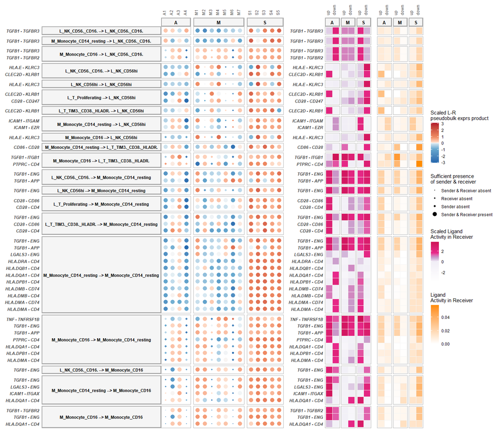

```r
prioritized_tbl_oi_S_50 = get_top_n_lr_pairs(multinichenet_output$prioritization_tables, 50, groups_oi = group_oi)

plot_oi = make_sample_lr_prod_activity_plots(multinichenet_output$prioritization_tables, prioritized_tbl_oi_S_50)
plot_oi
```

Now the entire top50 for the A group:

```r
group_oi = "A"
```

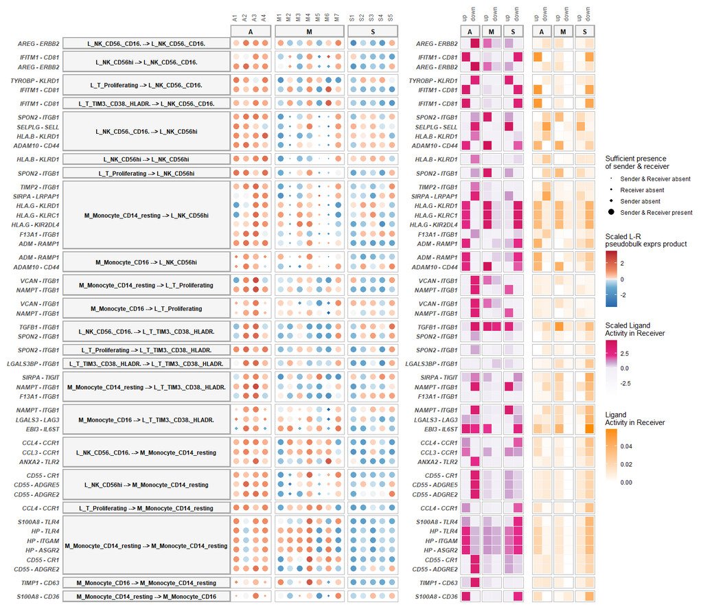

```r
prioritized_tbl_oi_A_50 = get_top_n_lr_pairs(multinichenet_output$prioritization_tables, 50, groups_oi = group_oi)

plot_oi = make_sample_lr_prod_activity_plots(multinichenet_output$prioritization_tables, prioritized_tbl_oi_A_50)
plot_oi
```

**Note**: Use `make_sample_lr_prod_activity_batch_plots` if you have batches and want to visualize them on this plot!

## Visualization of ligand-activity, ligand-target links, and target gene expression

In another type of plot, we can visualize the ligand activities for a group-receiver combination, and show the predicted ligand-target links, and also the expression of the predicted target genes across samples.

```r
group_oi = "M"
receiver_oi = "L_T_TIM3._CD38._HLADR."
prioritized_tbl_oi_M_10 = get_top_n_lr_pairs(multinichenet_output$prioritization_tables, 10, groups_oi = group_oi, receivers_oi = receiver_oi)
```

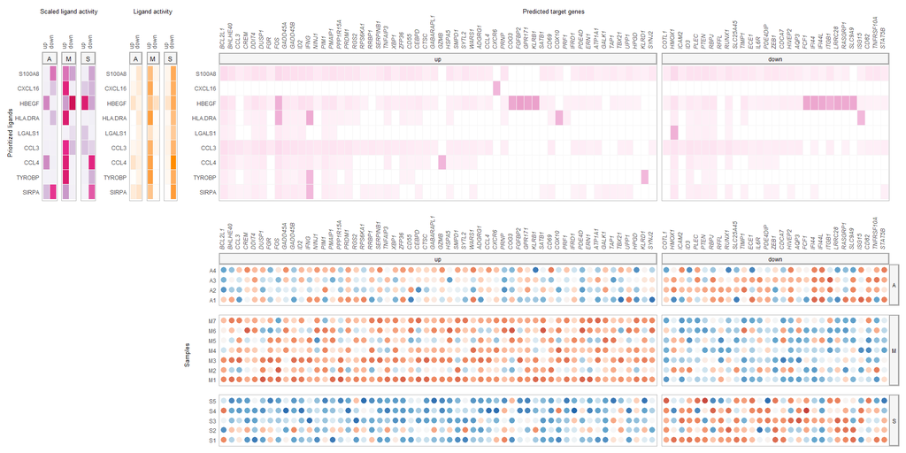

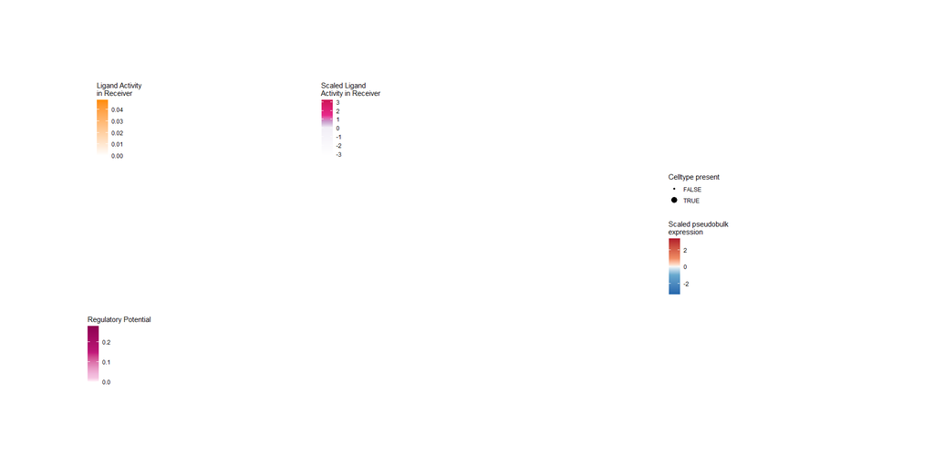

```r
combined_plot = make_ligand_activity_target_plot(group_oi, receiver_oi, prioritized_tbl_oi_M_10, multinichenet_output$prioritization_tables, multinichenet_output$ligand_activities_targets_DEgenes, contrast_tbl, multinichenet_output$grouping_tbl, multinichenet_output$celltype_info, ligand_target_matrix, plot_legend = FALSE)
combined_plot
## $combined_plot
```

Of course you can look at other receivers as well:

```r
group_oi = "M"
receiver_oi = "M_Monocyte_CD16"
prioritized_tbl_oi_M_10 = get_top_n_lr_pairs(multinichenet_output$prioritization_tables, 10, groups_oi = group_oi, receivers_oi = receiver_oi)
```

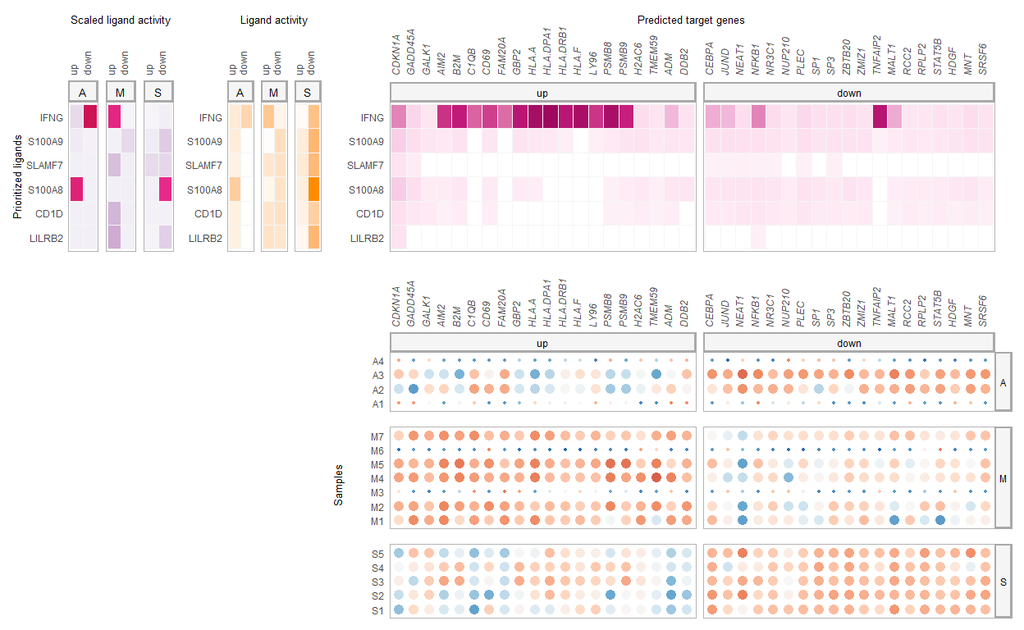

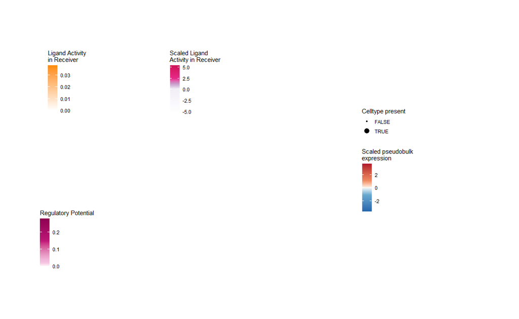

```r
combined_plot = make_ligand_activity_target_plot(group_oi, receiver_oi, prioritized_tbl_oi_M_10, multinichenet_output$prioritization_tables, multinichenet_output$ligand_activities_targets_DEgenes, contrast_tbl, multinichenet_output$grouping_tbl, multinichenet_output$celltype_info, ligand_target_matrix, plot_legend = FALSE)
combined_plot
## $combined_plot
```

## Show DE genes only:

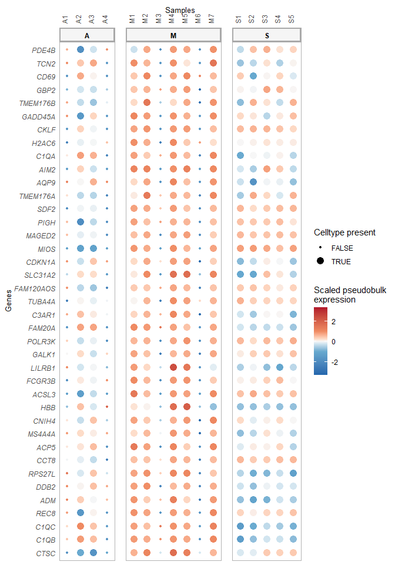

```r
group_oi = "M"
receiver_oi = "M_Monocyte_CD16"
targets_oi = multinichenet_output$ligand_activities_targets_DEgenes$de_genes_df %>% inner_join(contrast_tbl) %>% filter(group == group_oi) %>% arrange(p_val) %>% filter(receiver == receiver_oi & logFC > 1 & contrast == contrast_tbl %>% filter(group == group_oi) %>% pull(contrast)) %>% pull(gene) %>% unique()

p_target = make_DEgene_dotplot_pseudobulk(genes_oi = targets_oi, celltype_info = multinichenet_output$celltype_info, prioritization_tables = multinichenet_output$prioritization_tables, celltype_oi = receiver_oi, multinichenet_output$grouping_tbl)
p_target$pseudobulk_plot
```

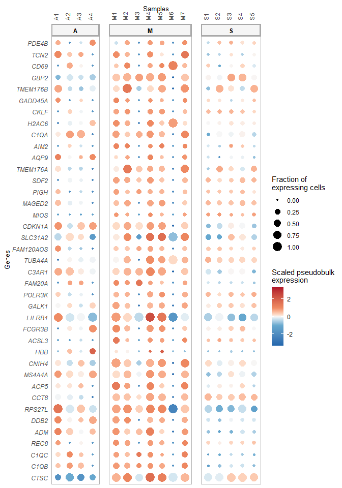

```r
p_target$singlecell_plot
```

**Note** Use `make_DEgene_dotplot_pseudobulk_batch` if you want to indicate the batch of each sample to the plot

## Visualization of expression-correlated target genes of ligand-receptor pairs

```r
group_oi = "M"
receiver_oi = "M_Monocyte_CD16"
lr_target_prior_cor_filtered = multinichenet_output$lr_target_prior_cor %>% inner_join(ligand_activities_targets_DEgenes$ligand_activities %>% distinct(ligand, target, direction_regulation, contrast)) %>% inner_join(contrast_tbl) %>% filter(group == group_oi, receiver == receiver_oi)
lr_target_prior_cor_filtered_up = lr_target_prior_cor_filtered %>% filter(direction_regulation == "up") %>% filter( (rank_of_target < top_n_target) & (pearson > 0.50 | spearman > 0.50))
lr_target_prior_cor_filtered_down = lr_target_prior_cor_filtered %>% filter(direction_regulation == "down") %>% filter( (rank_of_target < top_n_target) & (pearson < -0.50 | spearman < -0.50)) # downregulation -- negative correlation
lr_target_prior_cor_filtered = bind_rows(lr_target_prior_cor_filtered_up, lr_target_prior_cor_filtered_down)
```

Now we will visualize the top correlated hits for the LR pairs that are also in the top 50 LR pairs discriminating the groups from each other:

```r
prioritized_tbl_oi = get_top_n_lr_pairs(prioritization_tables, 50, groups_oi = group_oi, receivers_oi = receiver_oi)
```

First: show the LR–>Target heatmap of prior knowledge supported and correlated links (shows both measure of correlation and measure of prior knowledge)

For upregulated targets:

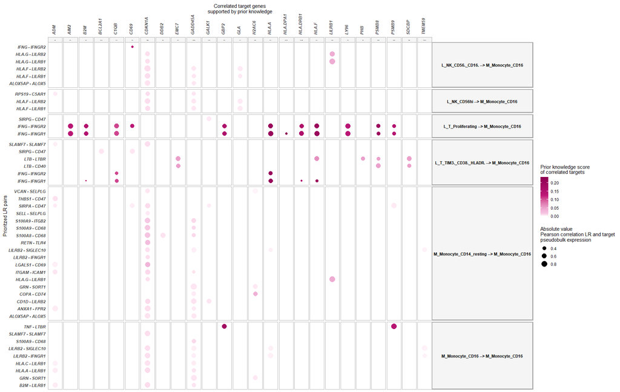

```r
lr_target_prior_cor_heatmap = make_lr_target_prior_cor_heatmap(lr_target_prior_cor_filtered_up %>% filter(receiver == receiver_oi & id %in% prioritized_tbl_oi$id), add_grid = TRUE)
lr_target_prior_cor_heatmap
```

For downregulated targets:

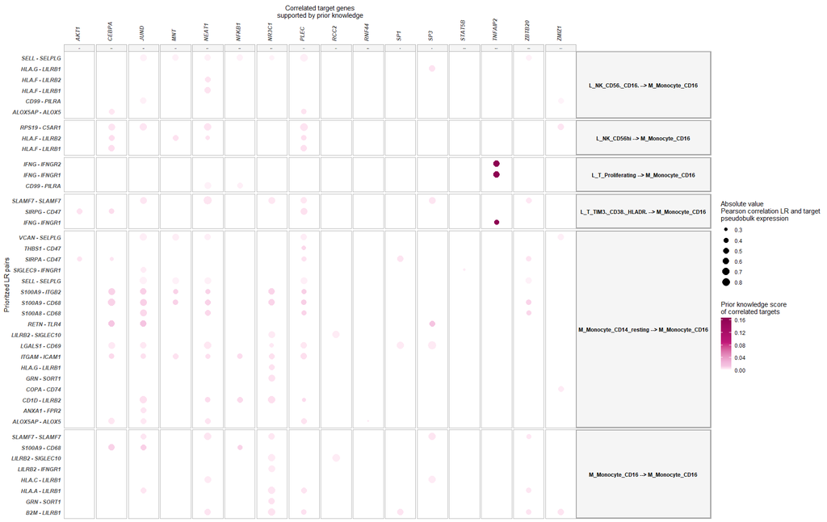

```r
lr_target_prior_cor_heatmap = make_lr_target_prior_cor_heatmap(lr_target_prior_cor_filtered_down %>% filter(receiver == receiver_oi & id %in% prioritized_tbl_oi$id), add_grid = TRUE)
lr_target_prior_cor_heatmap
```

Now visualize these links together with the LR and target expression, to visualize the expression correlation

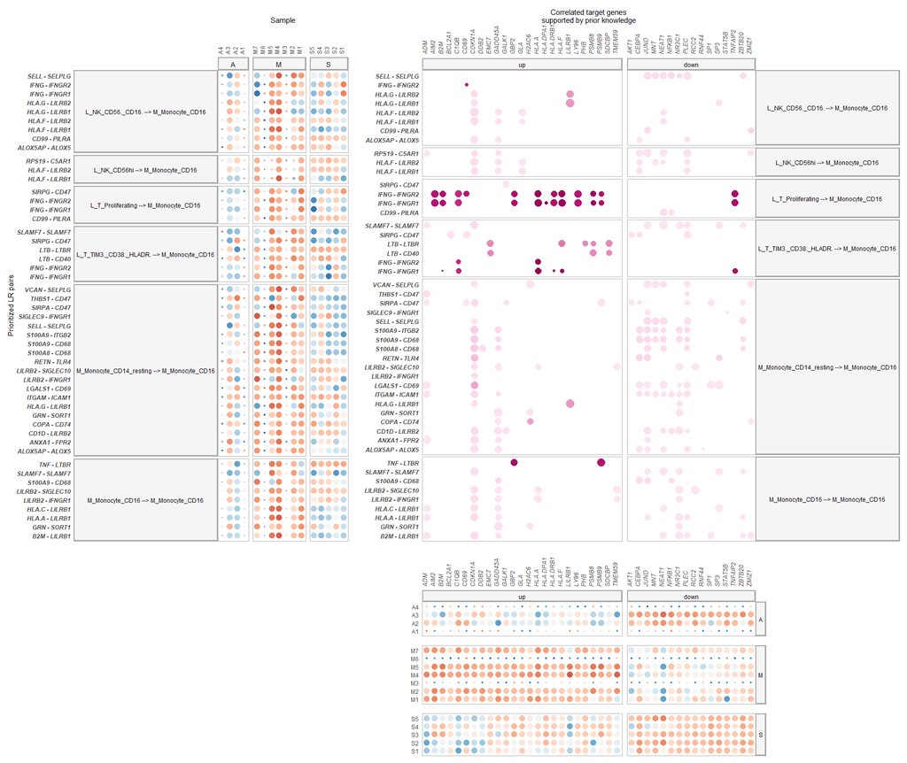

```r
lr_target_correlation_plot = make_lr_target_correlation_plot(multinichenet_output$prioritization_tables, prioritized_tbl_oi,  lr_target_prior_cor_filtered , multinichenet_output$grouping_tbl, multinichenet_output$celltype_info, receiver_oi,plot_legend = FALSE)
lr_target_correlation_plot$combined_plot
```

You can also visualize the expression correlation in the following way for a selected LR pair and their targets:

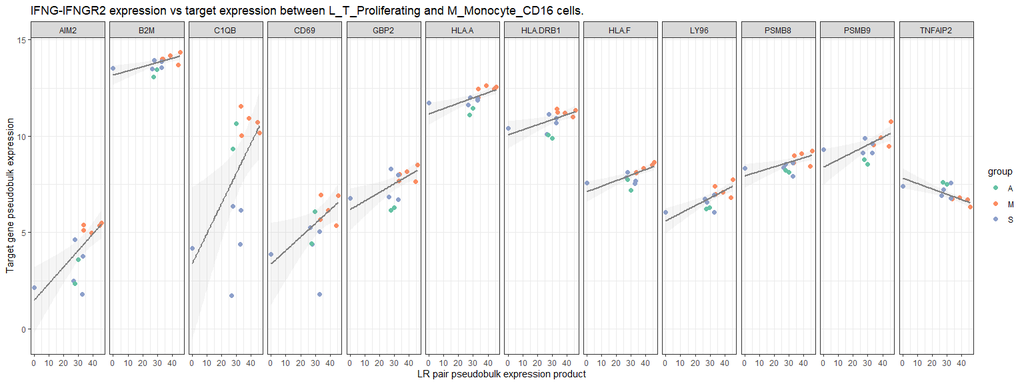

```r
ligand_oi = "IFNG"
receptor_oi = "IFNGR2"
sender_oi = "L_T_Proliferating"
receiver_oi = "M_Monocyte_CD16"
lr_target_scatter_plot = make_lr_target_scatter_plot(multinichenet_output$prioritization_tables, ligand_oi, receptor_oi, sender_oi, receiver_oi, multinichenet_output$celltype_info, multinichenet_output$grouping_tbl, lr_target_prior_cor_filtered)
lr_target_scatter_plot
```

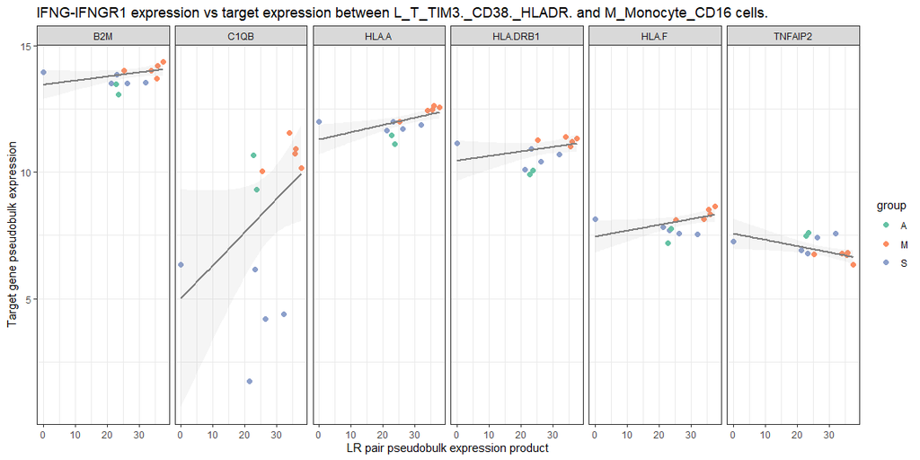

```r
ligand_oi = "IFNG"
receptor_oi = "IFNGR1"
sender_oi = "L_T_TIM3._CD38._HLADR."
receiver_oi = "M_Monocyte_CD16"
lr_target_scatter_plot = make_lr_target_scatter_plot(multinichenet_output$prioritization_tables, ligand_oi, receptor_oi, sender_oi, receiver_oi, multinichenet_output$celltype_info, multinichenet_output$grouping_tbl, lr_target_prior_cor_filtered)
lr_target_scatter_plot
```

For these targets, you can also visualize the ‘prior knowledge’ ligand-receptor-to-target signaling paths. This is done similarly to the workflow described in https://github.com/saeyslab/nichenetr/blob/master/vignettes/ligand_target_signaling_path.md

```r
organism = "human"
if(organism == "human"){
  sig_network = readRDS(url("https://zenodo.org/record/5884439/files/signaling_network_human_21122021.rds")) %>% mutate(from = make.names(from), to = make.names(to))
  gr_network = readRDS(url("https://zenodo.org/record/5884439/files/gr_network_human_21122021.rds")) %>% mutate(from = make.names(from), to = make.names(to))
  ligand_tf_matrix = readRDS(url("https://zenodo.org/record/5884439/files/ligand_tf_matrix_nsga2r_final.rds"))
  colnames(ligand_tf_matrix) = colnames(ligand_tf_matrix) %>% make.names()
  rownames(ligand_tf_matrix) = rownames(ligand_tf_matrix) %>% make.names()
  weighted_networks = readRDS(url("https://zenodo.org/record/5884439/files/weighted_networks_nsga2r_final.rds"))
  weighted_networks$lr_sig = weighted_networks$lr_sig %>% mutate(from = make.names(from), to = make.names(to))
  weighted_networks$gr = weighted_networks$gr %>% mutate(from = make.names(from), to = make.names(to))
} else if(organism == "mouse"){
  sig_network = readRDS(url("https://zenodo.org/record/5884439/files/signaling_network_mouse_21122021.rds")) %>% mutate(from = make.names(from), to = make.names(to))
  gr_network = readRDS(url("https://zenodo.org/record/5884439/files/gr_network_mouse_21122021.rds")) %>% mutate(from = make.names(from), to = make.names(to))
  ligand_tf_matrix = readRDS(url("https://zenodo.org/record/5884439/files/ligand_tf_matrix_nsga2r_final_mouse.rds"))
  colnames(ligand_tf_matrix) = colnames(ligand_tf_matrix) %>% make.names()
  rownames(ligand_tf_matrix) = rownames(ligand_tf_matrix) %>% make.names()
  weighted_networks = readRDS(url("https://zenodo.org/record/5884439/files/weighted_networks_nsga2r_final_mouse.rds"))
  weighted_networks$lr_sig = weighted_networks$lr_sig %>% mutate(from = make.names(from), to = make.names(to))
  weighted_networks$gr = weighted_networks$gr %>% mutate(from = make.names(from), to = make.names(to))
}
```

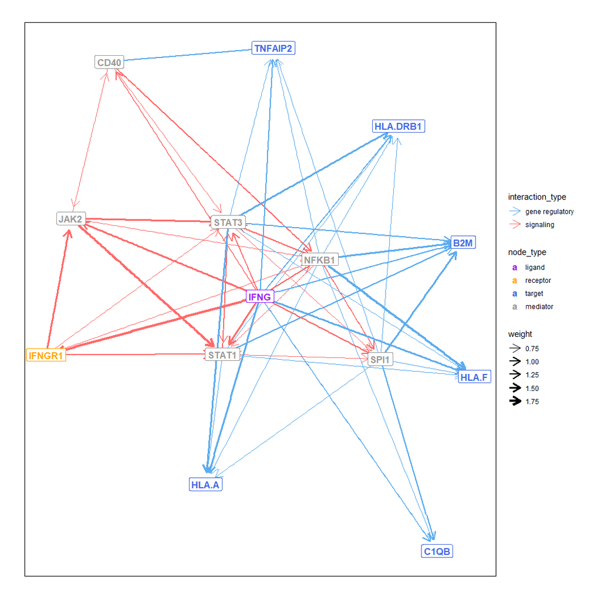

```r
targets_all = lr_target_prior_cor_filtered %>% filter(ligand == ligand_oi & receiver == receiver_oi & sender == sender_oi & receptor == receptor_oi)  %>% pull(target) %>% unique()

active_signaling_network = nichenetr::get_ligand_signaling_path_with_receptor(ligand_tf_matrix = ligand_tf_matrix, ligands_all = ligand_oi, receptors_all = receptor_oi, targets_all = targets_all, weighted_networks = weighted_networks, top_n_regulators = 2)
data_source_network = nichenetr::infer_supporting_datasources(signaling_graph_list = active_signaling_network,lr_network = lr_network, sig_network = sig_network, gr_network = gr_network)

active_signaling_network_min_max = active_signaling_network
active_signaling_network_min_max$sig = active_signaling_network_min_max$sig %>% mutate(weight = ((weight-min(weight))/(max(weight)-min(weight))) + 0.75)
active_signaling_network_min_max$gr = active_signaling_network_min_max$gr %>% mutate(weight = ((weight-min(weight))/(max(weight)-min(weight))) + 0.75)
colors = c("ligand" = "purple", "receptor" = "orange", "target" = "royalblue", "mediator" = "grey60")
ggraph_signaling_path = suppressWarnings(make_ggraph_signaling_path(active_signaling_network_min_max, colors, ligand_oi, receptor_oi, targets_all))
ggraph_signaling_path$plot
```

```r
data_source_network %>% head()
## # A tibble: 6 x 7
##   from  to      source                        database        layer      ligand receptor
##   <chr> <chr>   <chr>                         <chr>           <chr>      <chr>  <chr>
## 1 CD40  TNFAIP2 CytoSig_all                   CytoSig         regulatory <NA>   <NA>
## 2 CD40  TNFAIP2 CytoSig_signature             CytoSig         regulatory <NA>   <NA>
## 3 IFNG  B2M     lr_evex_regulation_expression evex_expression regulatory <NA>   <NA>
## 4 IFNG  B2M     CytoSig_signature             CytoSig         regulatory <NA>   <NA>
## 5 IFNG  B2M     NicheNet_LT_frequent          NicheNet_LT     regulatory <NA>   <NA>
## 6 IFNG  C1QB    CytoSig_all                   CytoSig         regulatory <NA>   <NA>
```

## Intercellular regulatory network systems view

In the plots before, we demonstrated that some DE genes have both expression correlation and prior knowledge support to be downstream of ligand-receptor pairs. Interestingly, some target genes can be ligands or receptors themselves. This illustrates that cells can send signals to other cells, who as a response to these signals produce signals themselves to feedback to the original sender cells, or who will effect other cell types.

As last plot, we can generate a ‘systems’ view of these intercellular feedback and cascade processes than can be occuring between the different cell populations involved. In this plot, we will draw links between ligands of sender cell types their ligand/receptor-annotated target genes in receiver cell types. So links are ligand-target links (= gene regulatory links) and not ligand-receptor protein-protein interactions!

```r
prioritized_tbl_oi = get_top_n_lr_pairs(prioritization_tables, 150, rank_per_group = FALSE)

lr_target_prior_cor_filtered = prioritization_tables$group_prioritization_tbl$group %>% unique() %>% lapply(function(group_oi){
  lr_target_prior_cor_filtered = multinichenet_output$lr_target_prior_cor %>% inner_join(ligand_activities_targets_DEgenes$ligand_activities %>% distinct(ligand, target, direction_regulation, contrast)) %>% inner_join(contrast_tbl) %>% filter(group == group_oi)
  lr_target_prior_cor_filtered_up = lr_target_prior_cor_filtered %>% filter(direction_regulation == "up") %>% filter( (rank_of_target < top_n_target) & (pearson > 0.50 | spearman > 0.50))
  lr_target_prior_cor_filtered_down = lr_target_prior_cor_filtered %>% filter(direction_regulation == "down") %>% filter( (rank_of_target < top_n_target) & (pearson < -0.50 | spearman < -0.50))
  lr_target_prior_cor_filtered = bind_rows(lr_target_prior_cor_filtered_up, lr_target_prior_cor_filtered_down)
}) %>% bind_rows()
```

[figure not shown]

```r
colors_sender["L_T_TIM3._CD38._HLADR."] = "pink" # the  original lightgreen with white font is not very readable
graph_plot = make_ggraph_ligand_target_links(lr_target_prior_cor_filtered = lr_target_prior_cor_filtered, prioritized_tbl_oi = prioritized_tbl_oi, colors = colors_sender)
graph_plot$plot
```

```r
graph_plot$source_df_lt %>% head()
## # A tibble: 6 x 6
##   sender                       receiver                        direction_regulation group type          weight
##   <chr>                        <chr>                           <fct>                <chr> <chr>          <dbl>
## 1 M_Monocyte_CD16_EBI3         L_T_TIM3._CD38._HLADR._LGALS3BP up                   A     Ligand-Target      1
## 2 L_NK_CD56._CD16._CCL4        M_Monocyte_CD14_resting_ADM     up                   A     Ligand-Target      1
## 3 L_T_Proliferating_CCL4       M_Monocyte_CD14_resting_ADM     up                   A     Ligand-Target      1
## 4 M_Monocyte_CD14_resting_CD55 M_Monocyte_CD14_resting_ADM     up                   A     Ligand-Target      1
## 5 L_NK_CD56hi_CD55             M_Monocyte_CD14_resting_ADM     up                   A     Ligand-Target      1
## 6 L_NK_CD56._CD16._CCL3        M_Monocyte_CD14_resting_ADM     up                   A     Ligand-Target      1
graph_plot$nodes_df %>% head()
##                                                      node                celltype gene       type_gene
## L_T_TIM3._CD38._HLADR._CD28   L_T_TIM3._CD38._HLADR._CD28  L_T_TIM3._CD38._HLADR. CD28 ligand/receptor
## M_Monocyte_CD14_resting_CD86 M_Monocyte_CD14_resting_CD86 M_Monocyte_CD14_resting CD86 ligand/receptor
## M_Monocyte_CD16_EBI3                 M_Monocyte_CD16_EBI3         M_Monocyte_CD16 EBI3          ligand
## L_NK_CD56._CD16._CCL4               L_NK_CD56._CD16._CCL4        L_NK_CD56._CD16. CCL4          ligand
## L_T_Proliferating_CCL4             L_T_Proliferating_CCL4       L_T_Proliferating CCL4          ligand
## M_Monocyte_CD14_resting_CD55 M_Monocyte_CD14_resting_CD55 M_Monocyte_CD14_resting CD55          ligand
```

## Show ligand activities for each receiver-group combination

In the next type of plot, we plot all the ligand activities (Both scaled and absolute activities) of each receiver-group combination. This can give us some insights in active signaling pathways across groups. Note that we can thus show top ligands based on ligand activity - agnostic of expression in sender.

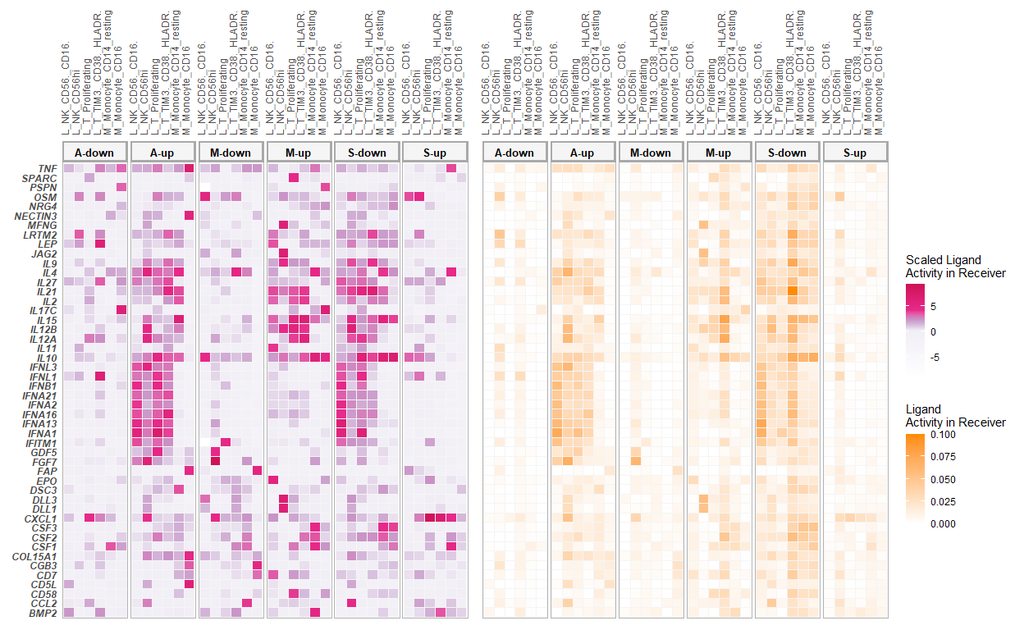

```r
ligands_oi = multinichenet_output$prioritization_tables$ligand_activities_target_de_tbl %>% inner_join(contrast_tbl) %>%
  group_by(group, receiver) %>% distinct(ligand, receiver, group, activity) %>%
  top_n(5, activity) %>% pull(ligand) %>% unique()

plot_oi = make_ligand_activity_plots(multinichenet_output$prioritization_tables, ligands_oi, contrast_tbl, widths = NULL)
plot_oi
```

## Zoom in on specific ligand-receptor interactions: show their expression in the single-cell data!

Single-cell-based Feature, and Violin plots of ligand-receptor interaction of interest: `make_ligand_receptor_feature_plot` and `make_ligand_receptor_violin_plot`

It is often useful to zoom in on specific ligand-receptor interactions of interest by looking in more detail to their expression at the single cell level

Check the highest scoring links based on the general prioritization score. Here we will pick one of those to visualize.

```r
prioritized_tbl_oi %>% head(10)
## # A tibble: 10 x 8
##    group sender                  receiver                ligand  receptor id                                                          prioritization_score prioritization_rank
##    <chr> <chr>                   <chr>                   <chr>   <chr>    <chr>                                                                      <dbl>               <dbl>
##  1 A     M_Monocyte_CD14_resting L_T_TIM3._CD38._HLADR.  NAMPT   ITGB1    NAMPT_ITGB1_M_Monocyte_CD14_resting_L_T_TIM3._CD38._HLADR.                  1.36                   1
##  2 A     M_Monocyte_CD16         L_T_TIM3._CD38._HLADR.  NAMPT   ITGB1    NAMPT_ITGB1_M_Monocyte_CD16_L_T_TIM3._CD38._HLADR.                          1.34                   2
##  3 M     L_T_Proliferating       M_Monocyte_CD14_resting IFNG    IFNGR2   IFNG_IFNGR2_L_T_Proliferating_M_Monocyte_CD14_resting                       1.31                   3
##  4 M     L_T_Proliferating       M_Monocyte_CD16         IFNG    IFNGR1   IFNG_IFNGR1_L_T_Proliferating_M_Monocyte_CD16                               1.31                   4
##  5 A     M_Monocyte_CD14_resting L_T_Proliferating       NAMPT   ITGB1    NAMPT_ITGB1_M_Monocyte_CD14_resting_L_T_Proliferating                       1.31                   5
##  6 M     L_T_TIM3._CD38._HLADR.  M_Monocyte_CD14_resting IFNG    IFNGR2   IFNG_IFNGR2_L_T_TIM3._CD38._HLADR._M_Monocyte_CD14_resting                  1.30                   6
##  7 M     L_T_TIM3._CD38._HLADR.  M_Monocyte_CD16         IFNG    IFNGR1   IFNG_IFNGR1_L_T_TIM3._CD38._HLADR._M_Monocyte_CD16                          1.30                   7
##  8 S     M_Monocyte_CD14_resting M_Monocyte_CD14_resting HLA.DMA CD4      HLA.DMA_CD4_M_Monocyte_CD14_resting_M_Monocyte_CD14_resting                 1.29                   8
##  9 M     M_Monocyte_CD16         L_T_Proliferating       HLA.DRA LAG3     HLA.DRA_LAG3_M_Monocyte_CD16_L_T_Proliferating                              1.28                   9
## 10 M     L_T_Proliferating       M_Monocyte_CD14_resting IFNG    IFNGR1   IFNG_IFNGR1_L_T_Proliferating_M_Monocyte_CD14_resting                       1.28                  10
```

```r
ligand_oi = "IFNG"
receptor_oi = "IFNGR1"
group_oi = "M"
sender_oi = "L_T_TIM3._CD38._HLADR."
receiver_oi = "M_Monocyte_CD16"
```

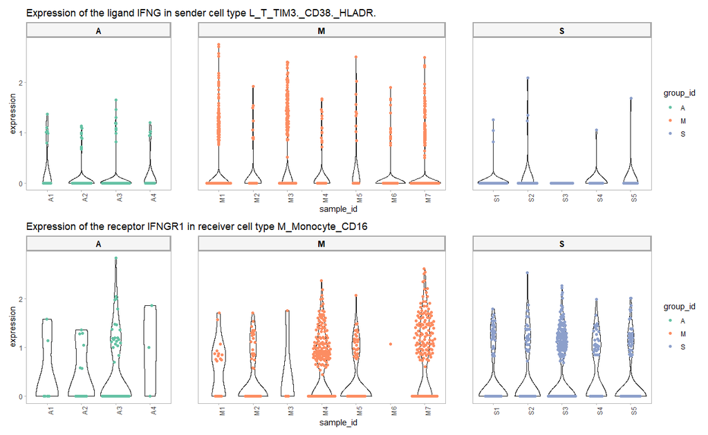

```r
p_violin = make_ligand_receptor_violin_plot(sce_sender = sce, sce_receiver = sce, ligand_oi = ligand_oi, receptor_oi = receptor_oi, group_oi = group_oi, group_id = group_id, sender_oi = sender_oi, receiver_oi = receiver_oi, sample_id = sample_id, celltype_id_sender = celltype_id, celltype_id_receiver = celltype_id)
p_violin
```

For `make_ligand_receptor_feature_plot`, your SingleCellExperiment object should have a dimensionality reduction element stored.

## Zoom in on specific ligand-target interactions: show their expression in the single-cell data!

Make target gene violin and feature plots: `make_target_violin_plot` and `make_target_feature_plot`

LILRB1: interesting gene in MIS-C CD16+ monocytes

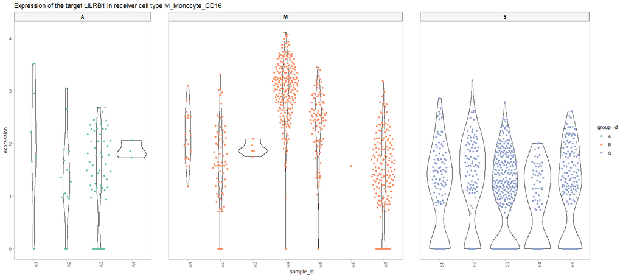

```r
target_oi = "LILRB1"

make_target_violin_plot(sce_receiver = sce, target_oi = target_oi, receiver_oi = receiver_oi, group_oi = group_oi, group_id = group_id, sample_id, celltype_id_receiver = celltype_id)
```